# Why are Employees Leaving

Kartik Nanduri

28 October, 2018

# Introduction

Employee attrition or churn can be defined as the process of an intellectual asset leaving from an organization, through regular means, such as retirement and resignation, the loss of customers or clients to old age or to growing out of the company’s target demographic. This type of reduction in staff is one way a company can decrease labor costs.

# Level - I Analysis

#### A quick look on dataset.

1. First six rows.

```
## # A tibble: 6 x 10
##   satisfaction_le~ last_evaluation number_project average_montly_~
##              <dbl>           <dbl>          <int>            <int>
## 1             0.38            0.53              2              157
## 2             0.8             0.86              5              262
## 3             0.11            0.88              7              272
## 4             0.72            0.87              5              223
## 5             0.37            0.52              2              159
## 6             0.41            0.5               2              153
## # ... with 6 more variables: time_spend_company <int>,
## #   Work_accident <int>, left <int>, promotion_last_5years <int>,
## #   Division <chr>, salary <chr>
```

2. Last six rows.

```
## # A tibble: 6 x 10
##   satisfaction_le~ last_evaluation number_project average_montly_~
##              <dbl>           <dbl>          <int>            <int>
## 1             0.76           0.83               6              293
## 2             0.4            0.570              2              151
## 3             0.37           0.48               2              160
## 4             0.37           0.53               2              143
## 5             0.11           0.96               6              280
## 6             0.37           0.52               2              158
## # ... with 6 more variables: time_spend_company <int>,
## #   Work_accident <int>, left <int>, promotion_last_5years <int>,
## #   Division <chr>, salary <chr>
```

3. Checking for null/missing values

```
##    satisfaction_level       last_evaluation        number_project
##                     0                     0                     0
##  average_montly_hours    time_spend_company         Work_accident
##                     0                     0                     0
##                  left promotion_last_5years              Division
##                     0                     0                     0
##                salary
##                     0
```

#### Structure of the dataset

```
## Classes 'tbl_df', 'tbl' and 'data.frame':    14999 obs. of  10 variables:
##  $ satisfaction_level   : num  0.38 0.8 0.11 0.72 0.37 0.41 0.1 0.92 0.89 0.42 ...
##  $ last_evaluation      : num  0.53 0.86 0.88 0.87 0.52 0.5 0.77 0.85 1 0.53 ...
##  $ number_project       : int  2 5 7 5 2 2 6 5 5 2 ...
##  $ average_montly_hours : int  157 262 272 223 159 153 247 259 224 142 ...
##  $ time_spend_company   : int  3 6 4 5 3 3 4 5 5 3 ...
##  $ Work_accident        : int  0 0 0 0 0 0 0 0 0 0 ...
##  $ left                 : int  1 1 1 1 1 1 1 1 1 1 ...
##  $ promotion_last_5years: int  0 0 0 0 0 0 0 0 0 0 ...
##  $ Division             : chr  "sales" "sales" "sales" "sales" ...
##  $ salary               : chr  "low" "medium" "medium" "low" ...
##  - attr(*, "spec")=List of 2
##   ..$ cols   :List of 10
##   .. ..$ satisfaction_level   : list()
##   .. .. ..- attr(*, "class")= chr  "collector_double" "collector"
##   .. ..$ last_evaluation      : list()
##   .. .. ..- attr(*, "class")= chr  "collector_double" "collector"
##   .. ..$ number_project       : list()
##   .. .. ..- attr(*, "class")= chr  "collector_integer" "collector"
##   .. ..$ average_montly_hours : list()
##   .. .. ..- attr(*, "class")= chr  "collector_integer" "collector"
##   .. ..$ time_spend_company   : list()
##   .. .. ..- attr(*, "class")= chr  "collector_integer" "collector"
##   .. ..$ Work_accident        : list()
##   .. .. ..- attr(*, "class")= chr  "collector_integer" "collector"
##   .. ..$ left                 : list()
##   .. .. ..- attr(*, "class")= chr  "collector_integer" "collector"
##   .. ..$ promotion_last_5years: list()
##   .. .. ..- attr(*, "class")= chr  "collector_integer" "collector"
##   .. ..$ Division             : list()
##   .. .. ..- attr(*, "class")= chr  "collector_character" "collector"
##   .. ..$ salary               : list()
##   .. .. ..- attr(*, "class")= chr  "collector_character" "collector"
##   ..$ default: list()
##   .. ..- attr(*, "class")= chr  "collector_guess" "collector"
##   ..- attr(*, "class")= chr "col_spec"
```

- We see that there are inconsistencies in column names as well as their values.
- Let’s remove these inconsistencies.

```
## Classes 'tbl_df', 'tbl' and 'data.frame':    14999 obs. of  10 variables:
##  $ satisfaction_level  : num  0.38 0.8 0.11 0.72 0.37 0.41 0.1 0.92 0.89 0.42 ...
##  $ last_evaluation     : num  0.53 0.86 0.88 0.87 0.52 0.5 0.77 0.85 1 0.53 ...
##  $ number_project      : int  2 5 7 5 2 2 6 5 5 2 ...
##  $ average_montly_hours: int  157 262 272 223 159 153 247 259 224 142 ...
##  $ time_spend_company  : int  3 6 4 5 3 3 4 5 5 3 ...
##  $ work_acc            : chr  "no" "no" "no" "no" ...
##  $ left                : chr  "yes" "yes" "yes" "yes" ...
##  $ promoted_last_5yrs  : chr  "no" "no" "no" "no" ...
##  $ division            : chr  "sales" "sales" "sales" "sales" ...
##  $ salary              : Ord.factor w/ 3 levels "low"<"medium"<..: 1 2 2 1 1 1 1 1 1 1 ...
```

#### Let us check the distributions of the following dimensions:

1. `satisfaction_level`
2. `last_evaluation`
3. `number_project`
4. `average_montly_hours`
5. `time_spend_company`

#### 1. Statisfaction level

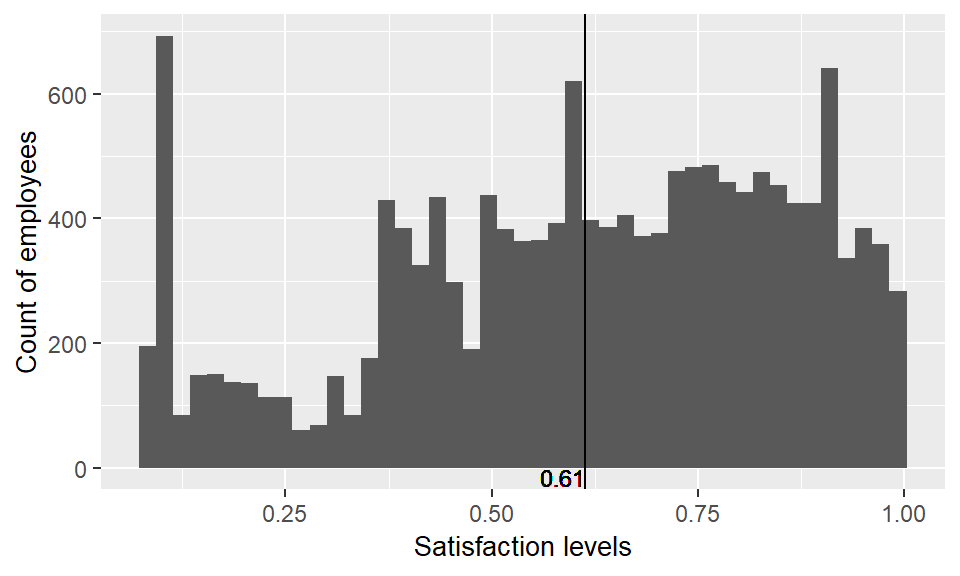

Figure: Distribution of satisfaction_level.

- We see that the average satisfaction level of employees is around **`~ .61`** or about **`~ 61%`**.

#### 2. Last evaluation

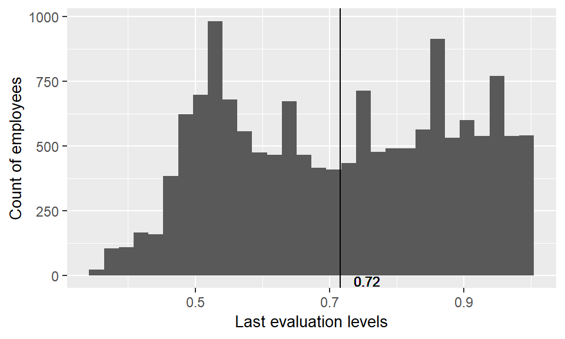

Figure: Distribution of last_evaluation.

- Average evaluation of the employees is around **`0.72`** or about **`~ 72%`**.

#### 3. Number of projects

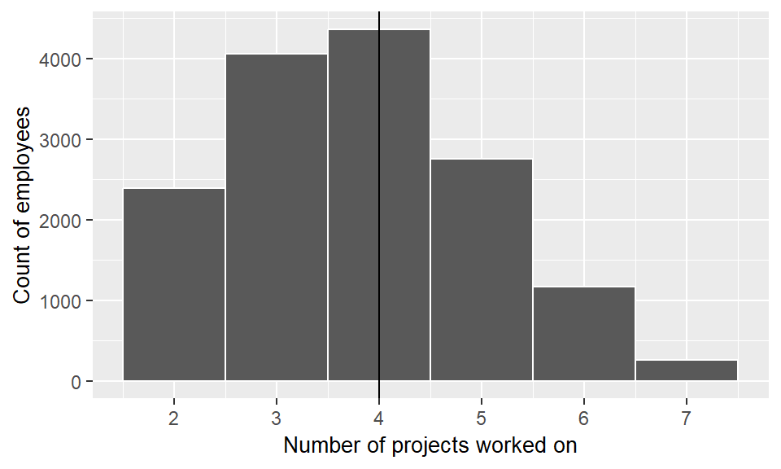

Figure: Distribution of number_project.

- The median for number_project is `4`, thus dividing our dataset into two parts.

#### 4. Average montly hours

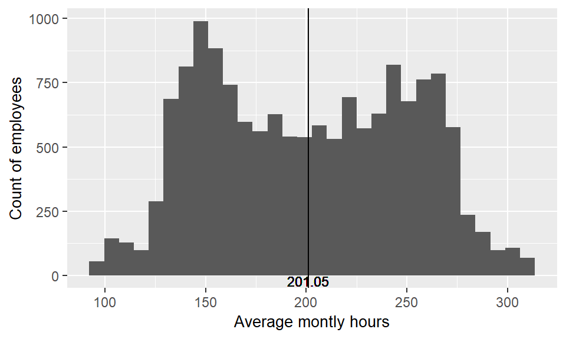

Figure: Distribution of average_montly_hours.

- Each employee spends about **`~ 200`** hours each month, that is exproximately **`8.33`** hours a day.

#### 5. Time spent in the company

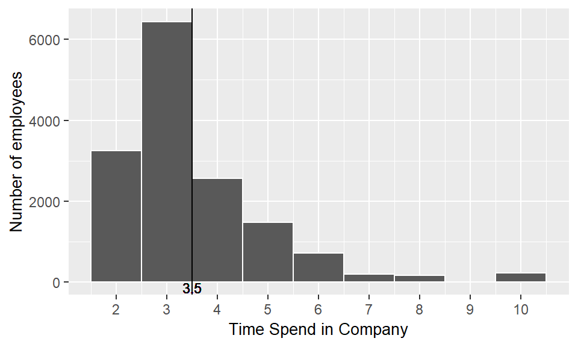

Figure: Distribution of time_spend_company.

- Employees spend about **`3 ~ 4`** years on an average in the organization.

#### Let us check how many employees fall under for the following dimensions:

1. `work_acc`
2. `left`
3. `promoted_last_5yrs`
4. `division`
5. `salary`

#### 1. Number of accidents at work.

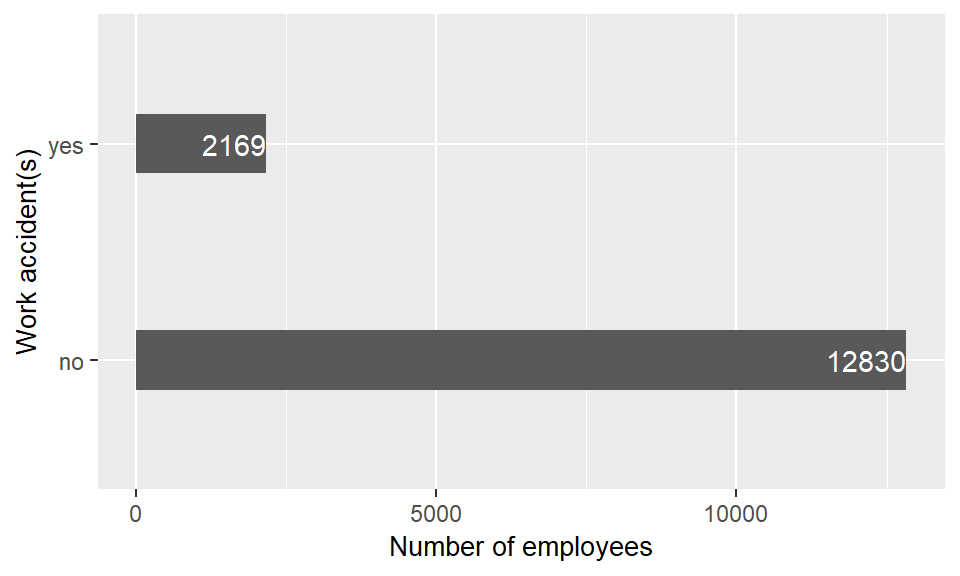

Figure: Work accidents.

- we have around 2169 work accidents, that is **`~ 14%`**.

#### 2. Number of people who have left the organization.

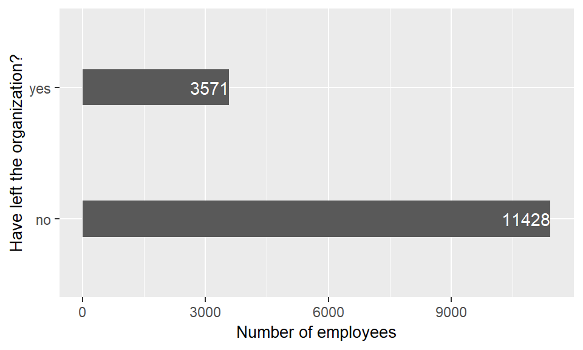

Figure: People who have left the organization.

- about **`3571`** employees are no longer associated with the organinzation.

#### 3. How many employees have been promoted in last five years in the organization.

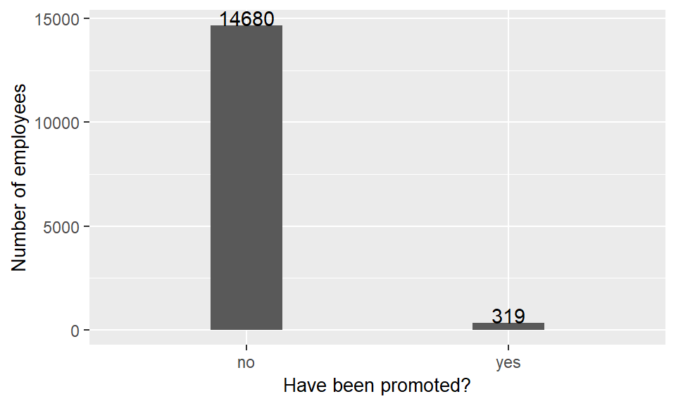

Figure: Promotions in last five years.

- out of 14999 employees only **`319`** have been promoted in the last five years; that is, **`~ 2%`** of the total employees in the dataset.

#### 4. How many employees belong to the same division in the organization.

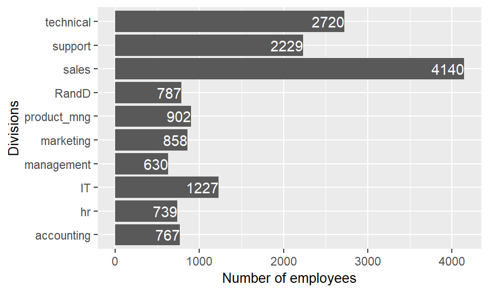

Figure: Divisions in the organization.

- we see that, the division **`sales`** has most of the employees, followed by **`technical`** and **`support`** divisions.

#### 5. How many of them belong to same pay-grade in the organization.

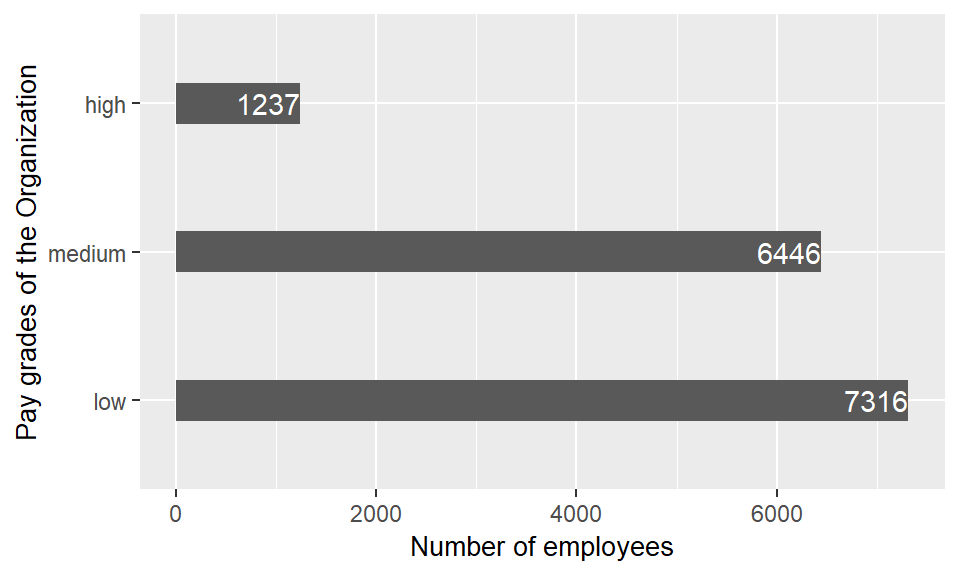

Figure: People of same pay-grade.

- Majority of the employees have **`low`** pay grade, can this be the reason for attrition in this organization.

# Level - II Analysis

- We have explored the dataset and we have found that our target variable for further analysis is **`left`**, thus leaving us with following questions:

#### Does the organization need to worry about percentage churn in employment?

- to answer the above the question, let us plot a `pie chart` and see the significance.

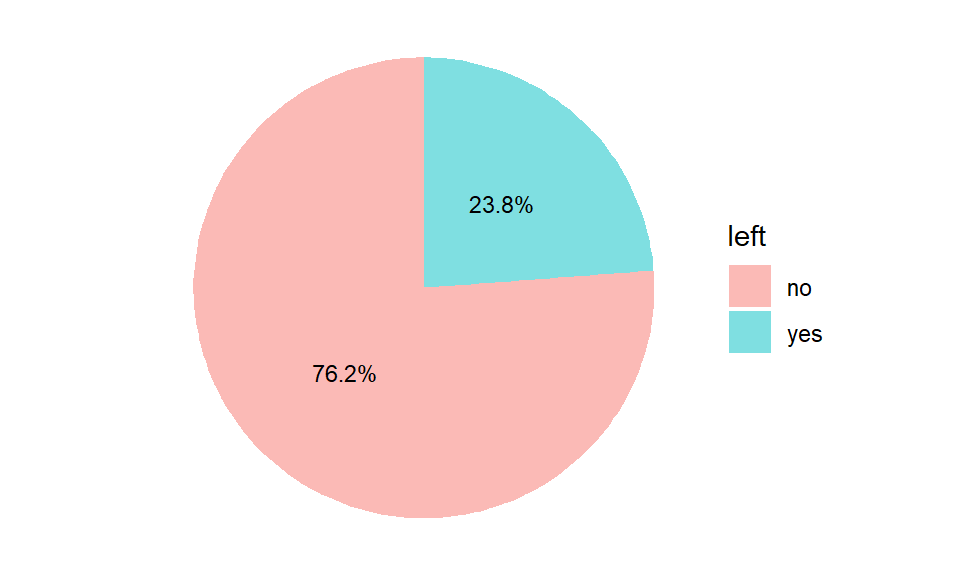

Figure: % churn in employment.

- from the chart we can infer that about **`~25%`** of the total employees, have left the company.

#### So, the next question here is that - does the percentage churn belong to a particular division or is it organization-wide?

- plotting a stacked column will answer the above question.

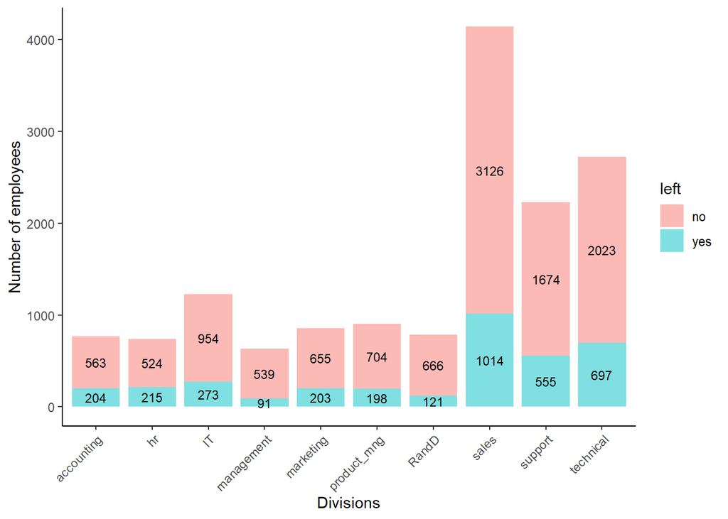

Figure: Churn in each division

- from the above chart we can conclude that the `sales` division has lost most of it employees, but is this true?.
- let us plot a 100% stacked column of `left` over `division`, to see if there is a problem in `sales` division.

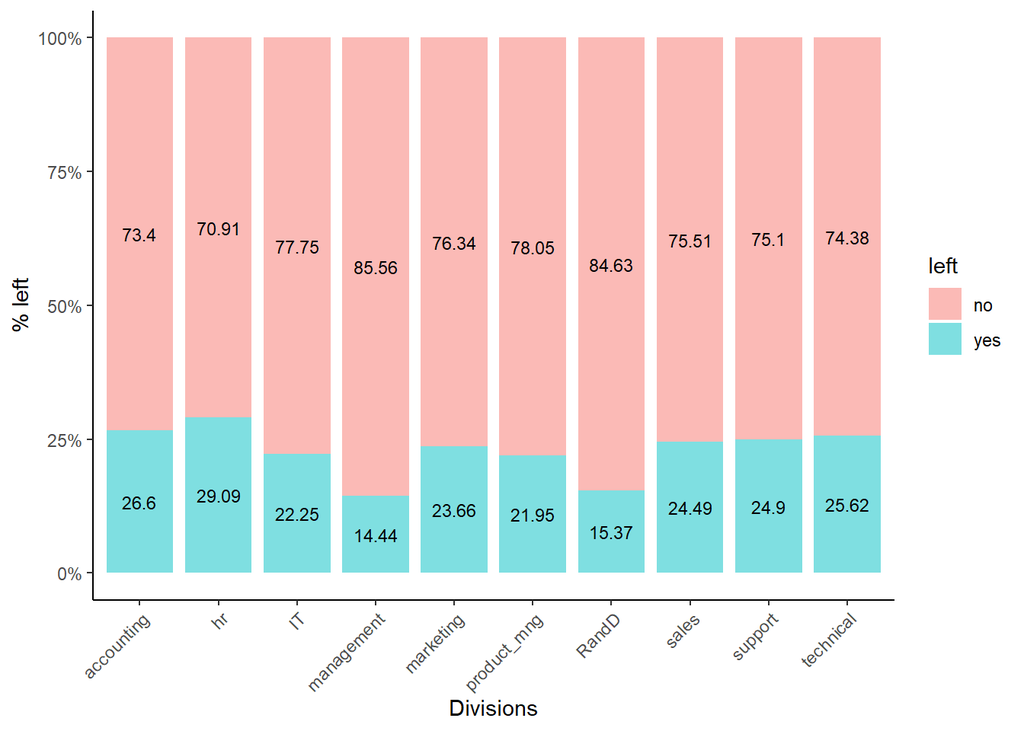

Figure: Percentage churn in each division

# Level - III Analysis

- As the problem is organization-wide, by looking at the names of columns/dimensions of our dataset, two fields standout:
  - `satisfaction_level` : determines how happy a employee is with the company.
  - `last_evaluation` : determines the employees’ performace over a period.
- This raises the following question.

#### Who has left?

- Given that we have various types of performers in an organization, we will use the above fields/dimensions to carry out further analysis.
- A scatterplot between the two would give us an idea about the correlation between the two variables.

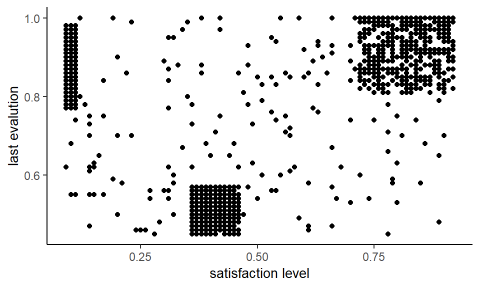

Figure: Identifying clustures for satisfaction levels vs last evaluations

- By looking the polt we can see that, there are three distinct clustures that have been formed, let us name these clustures.
  - statisfaction level `[0.25, 0.50]` and last evaluation `[0.20, 0.60]`: `Bad Fit`.
  - statisfaction level `[0.00, 0.20]` and last evaluation `[0.60, 1.0]`: `Unfulfilled`.
  - statisfaction level `[0.50, 1.0]` and last evaluation `[0.60, 1.0]`: `Best Fit`.
  - Note: **`[]`** represent the use of closed intervals.
- Let us add these employee types to our dataset and carry out futher analysis on the these employee types.

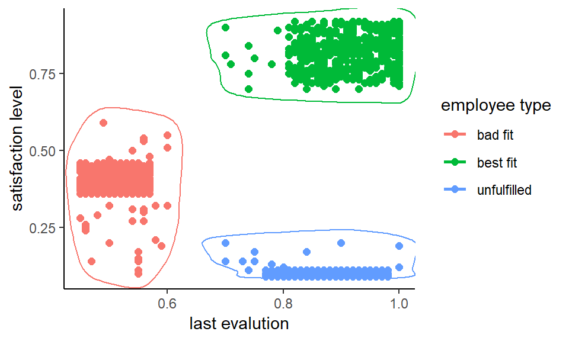

Figure: Clustures for satisfaction levels vs last evaluations by employee type.

#### Do these three employee types contribute to attrition in specific division or it is organization-wide?

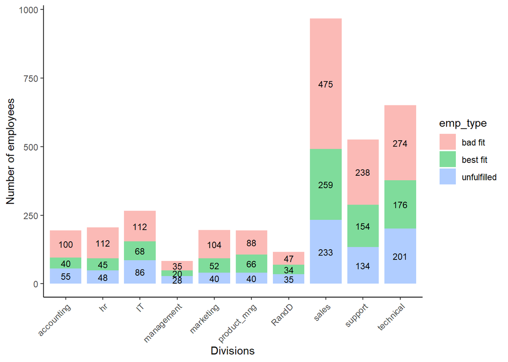

Figure: Employee types in each division

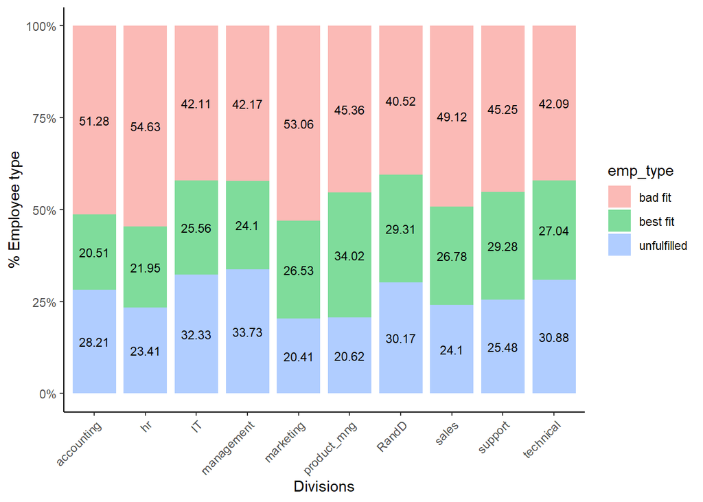

Figure: % Employee types in each division

- We can conclude that, there is no specific employee type that is contributing to attrition in divisions; that is, attrition of employee types in each division is the same.
  - `bad fit`: **40% - 55%**
  - `good fit`: **20% - 35%**
  - `unfulfilled`: **20% - 34%**

#### As we have identified the following employee types in this organization, let us explore each of the three employee types; that is, why did they leave the organization?

#### Plotting the following graphs will reveal why these employee types have left the organization.

1. Distribution of Average monthly hours.
2. Promotions in last five years
3. Pay grade
4. Work accidents
5. Number of projects that were worked on.
6. Tenure of the employment

#### 1. Analysis for Employee type - `Unfulfilled`.

1. Distribution of Average monthly hours.

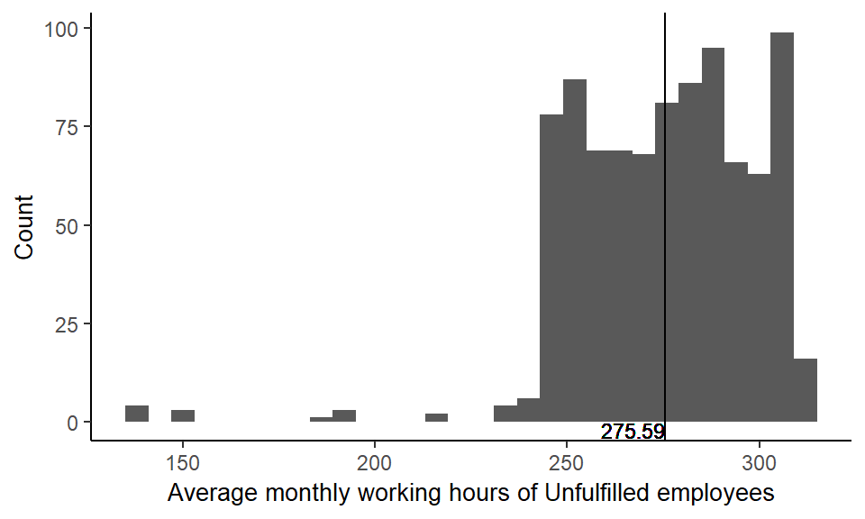

Figure: How many hours do unfulfilled people work?

2. Promotions in last five years

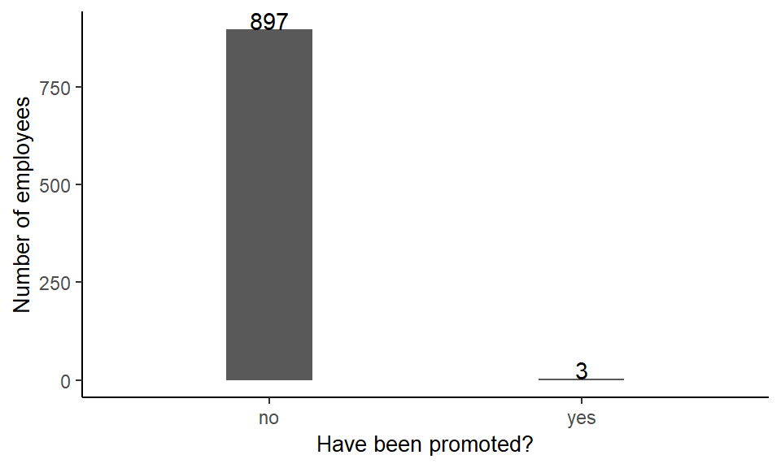

Figure: How many unfulfilled people at work get promoted?

3. Pay grade

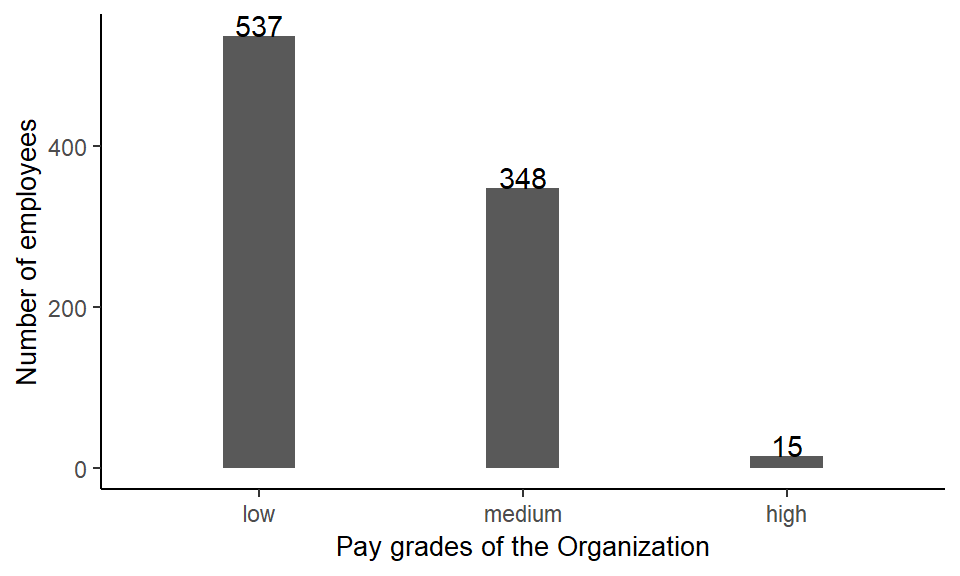

Figure: To which pay grade do unfulfilled people belong?

4. Work accidents

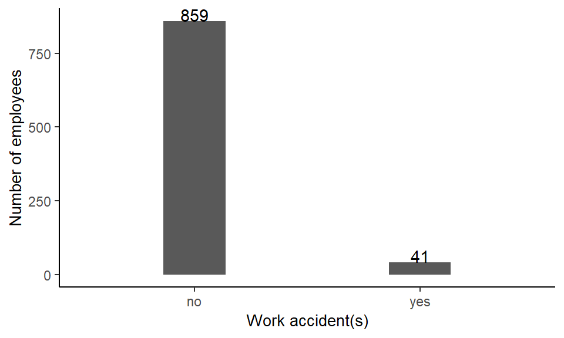

Figure: How many work accident were unfulfilled people involved in?

5. Number of projects that were worked on.

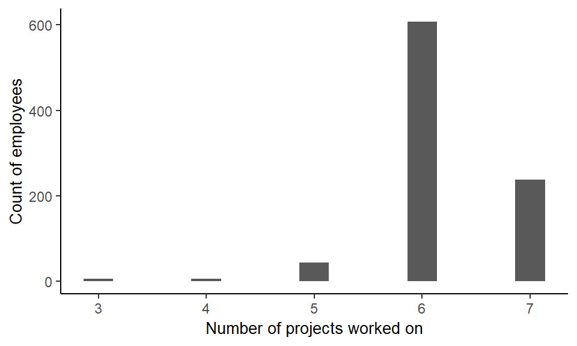

Figure: How many projects did unfulfilled people work at?

6. Tenure of employment

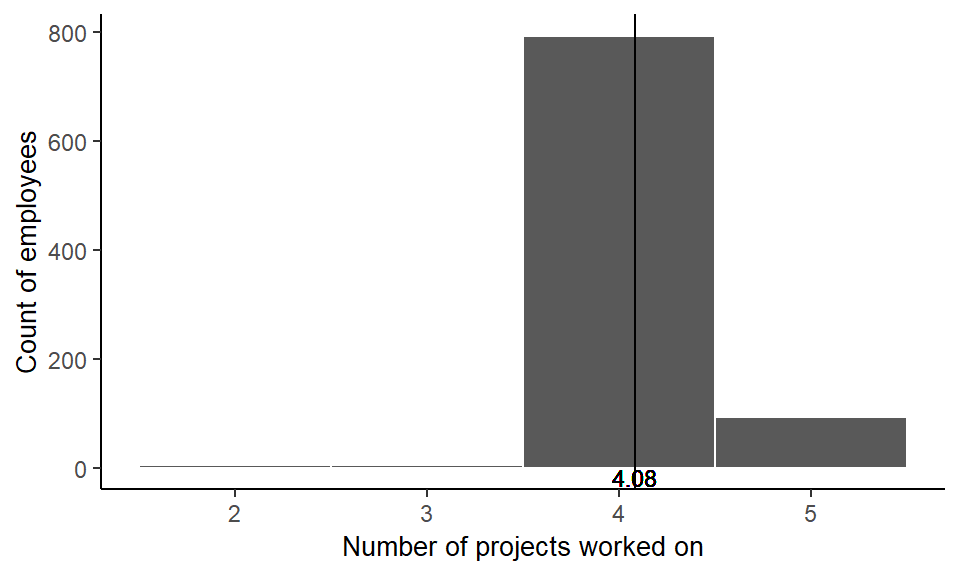

Figure: How long do unfulfilled people stay with the organization?

#### Conclusions for Unfulfilled employees.

- These people have put in alot of effort and are requested/required to work for approxmately **`276 hours`** a month; i.e., approximately **`276/24 ~= 11.5 hours/day`**.
- They are paid very less, and are asked to work on **`6 ~ 7`** project at a time, for which they are appricated and not promoted.
- 4% `(41/900)` of the people leave because of work accidents.
- They stay for approximately **`4 years`** before they leave the company.

#### 2. Analysis for Employee type - `Good Fit`.

1. Distribution of Average monthly hours.

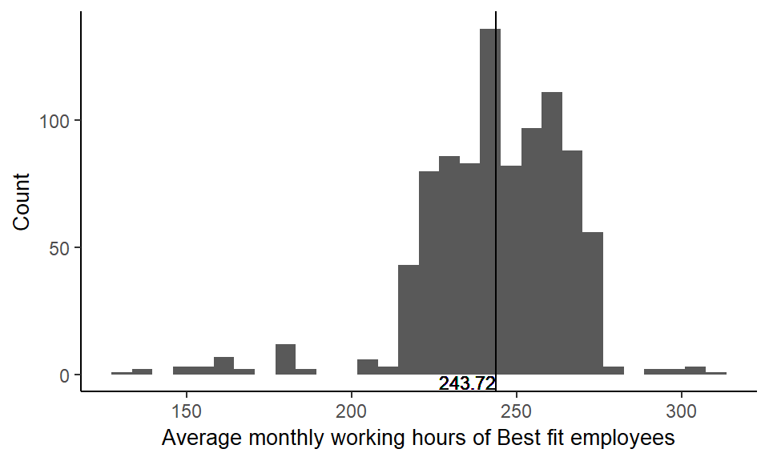

Figure: How many hours do best fit people work?

2. Promotions in last five years

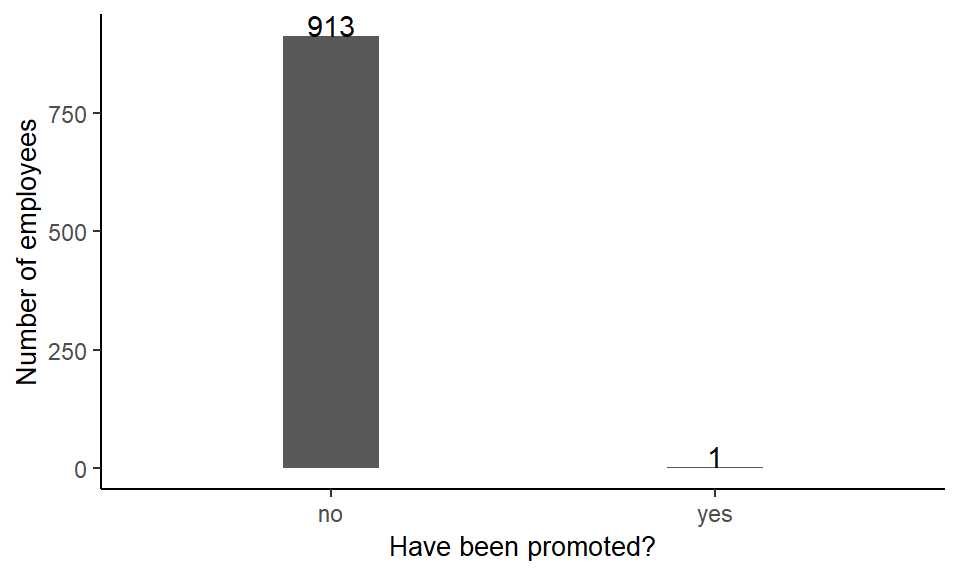

Figure: How many best fit people at work get promoted?

3. Pay grade

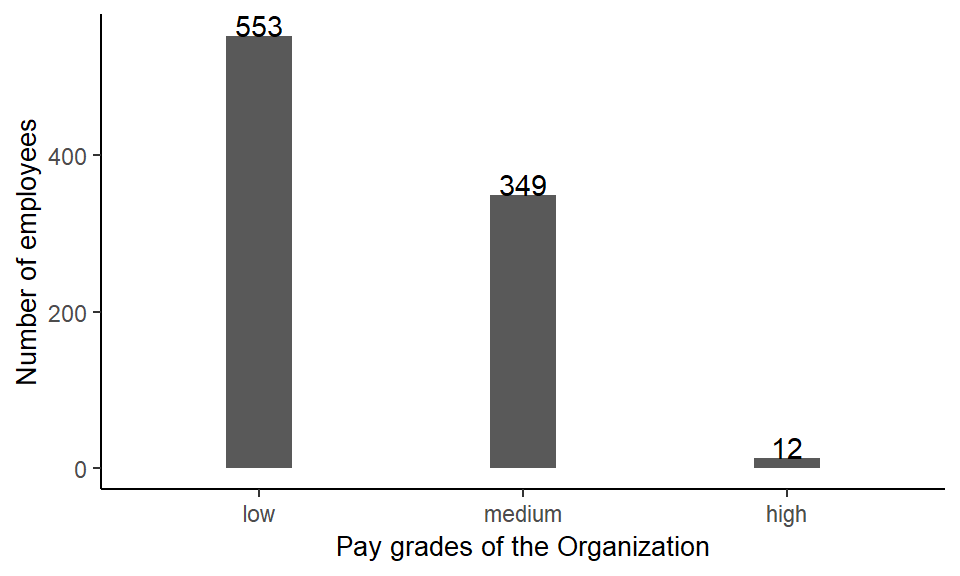

Figure: To which pay grade do best fit people belong?

4. Work accidents

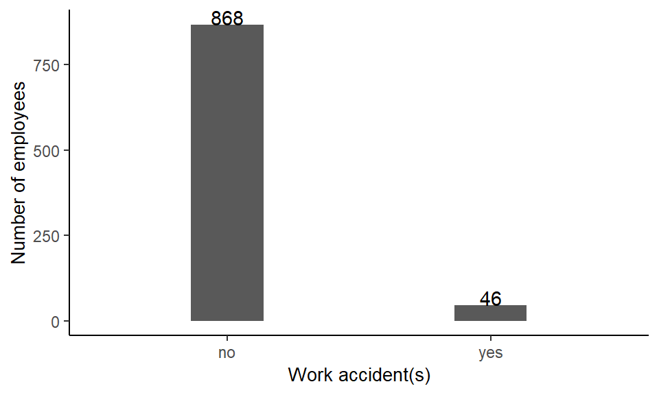

Figure: How many work accident were best fit people involved in?

5. Number of projects that were worked on.

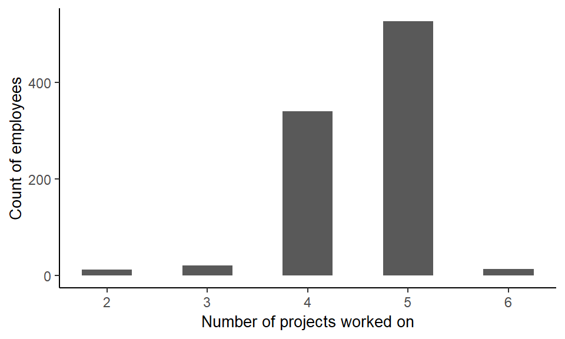

Figure: How many projects did best fit people work at?

6. Tenure of employment

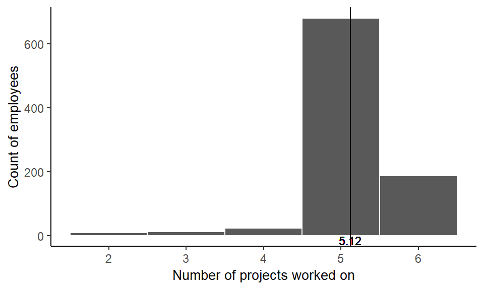

Figure: How long do best fit people stay with the organization?